# Proceso del Analisis Factorial Exploratorio (EFA)

# Ejercicio 1: Base de datos de departamentos

## Paso 0: Seleccionamos subdata

Abrimos la base de datos:

```r
library(rio)
regiones<- import("https://github.com/DataPolitica/salidas/raw/master/Data/regiones_total.xlsx")
head(regiones)
```

|  | n | Región | casos | casos_t | fallecidos | fallecidos_t | poblacion | poblacion_100k | altura_media_capital | pobreza | vias_pavimentadas | problema_salud_cronico | esperanza_vida | agua | desague | electrificacion | medicos_colegiados | PBI_percapita | presupuestopublico_percapita | ejecución_inversion_publica | PEA_informal | analfabetismo | poblacion_secundaria |
| --- | --- | --- | --- | --- | --- | --- | --- | --- | --- | --- | --- | --- | --- | --- | --- | --- | --- | --- | --- | --- | --- | --- | --- |
| 1 | 1 | Amazonas | 9968 | 2627.4171 | 190 | 50.08118 | 379384 | 3.79384 | 2483 | 47.3 | 42.0695 | 42.41115 | 71.65 | 51.84 | 36.69 | 73.67 | 262 | 6820.929 | 446.2813 | 72.9082 | 85.3501 | 8.4242 | 41.2392 |
| 2 | 2 | Ancash | 17314 | 1597.9415 | 1141 | 105.30503 | 1083519 | 10.83519 | 3050 | 23.5 | 30.7078 | 41.37640 | 74.86 | 71.56 | 56.38 | 85.20 | 2741 | 16846.823 | 509.8968 | 53.1842 | 80.3267 | 9.5630 | 51.4177 |
| 3 | 3 | Apurímac | 2448 | 603.3138 | 60 | 14.78710 | 405759 | 4.05759 | 2500 | 42.8 | 34.6249 | 40.20969 | 71.44 | 56.33 | 36.12 | 80.43 | 508 | 14738.951 | 519.3545 | 61.7492 | 88.0408 | 14.0318 | 43.6943 |
| 4 | 4 | Arequipa | 30441 | 2201.5144 | 1106 | 79.98669 | 1382730 | 13.82730 | 2335 | 9.1 | 28.3488 | 33.07475 | 77.13 | 72.47 | 65.85 | 89.98 | 2195 | 23096.513 | 403.1003 | 61.5159 | 65.2675 | 3.5449 | 68.1574 |
| 5 | 5 | Ayacucho | 7407 | 1202.0916 | 253 | 41.05970 | 616176 | 6.16176 | 2746 | 51.9 | 34.5617 | 29.67002 | 72.01 | 66.99 | 45.35 | 80.94 | 560 | 7783.191 | 462.4479 | 67.7971 | 87.0986 | 11.8598 | 46.1963 |
| 6 | 6 | Cajamarca | 13860 | 1033.5478 | 377 | 28.11310 | 1341012 | 13.41012 | 2750 | 52.9 | 38.8711 | 28.28153 | 74.03 | 52.89 | 32.48 | 80.68 | 464 | 7081.692 | 326.7535 | 61.0216 | 89.3412 | 11.5018 | 35.7519 |

Realizamos un subset y nos quedamos con las variables que utilizaremos. Lo llamaremos **subdata**:

- nos aseguramos que usamos la variables que seleccionamos (agua, desgue, electrificacion,PBI…)

```r
subdata<- regiones[,c(11, 14:16, 18:19)]
```

## Paso 1: Matriz de correlaciones

Generamos la matriz de correlaciones para identificar qué variables de nuestra subdata están correlacionadas.

```r
library(polycor)
```

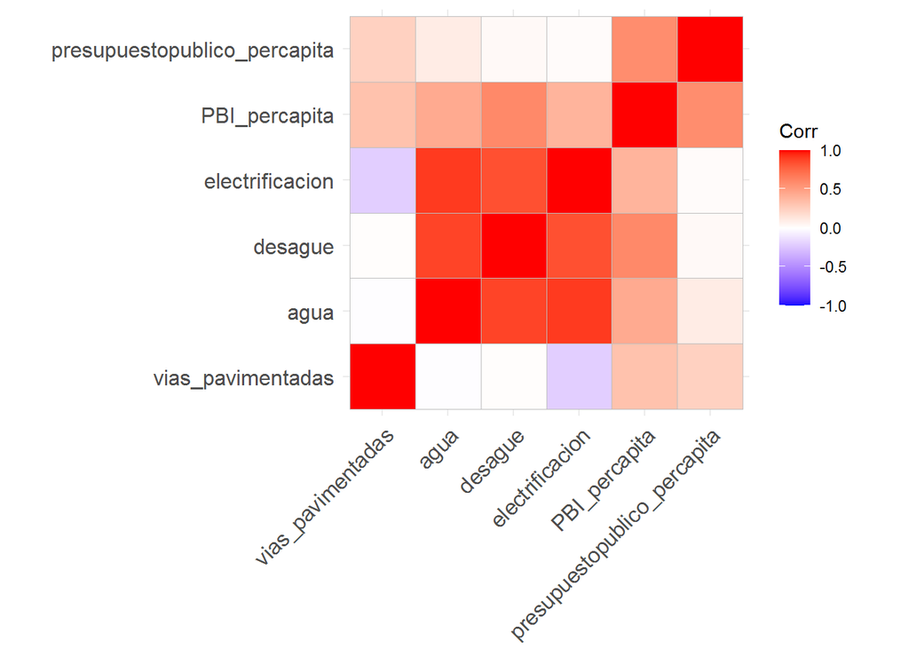

```r
matriz<-hetcor(subdata)
matriz_corr<- matriz$correlations
library(ggcorrplot)
ggcorrplot(matriz_corr)
```

Vemos las correlaciones significativas: Si puedes ver bloques correlacionados hay esperanza de un buen analisis factorial.

-ver en el gaafico con cuadrados MAS INTENSOS

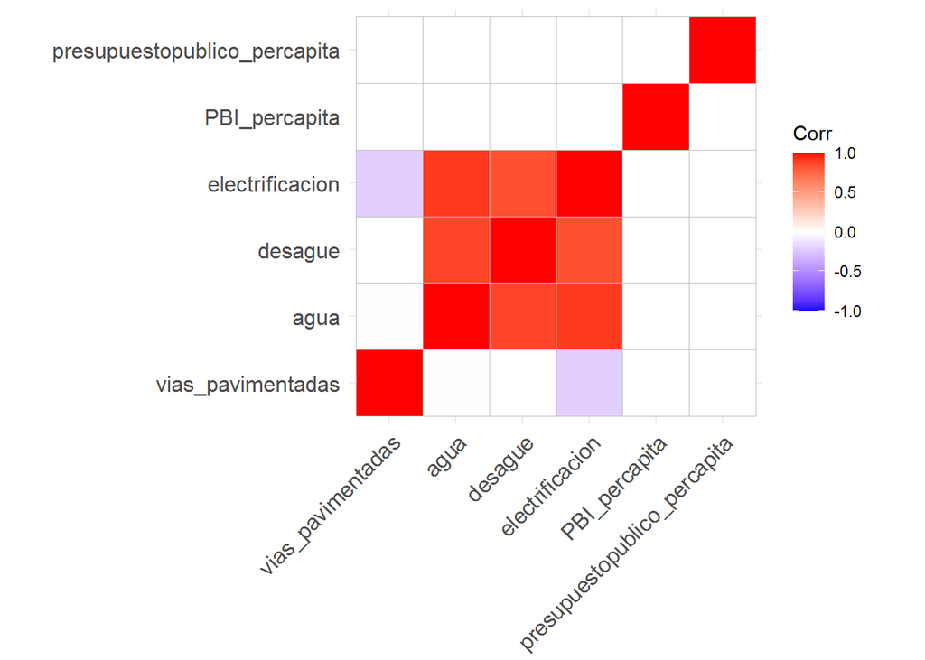

```r
ggcorrplot(matriz_corr,
           p.mat = cor_pmat(matriz_corr),
           insig = "blank")
```

```r
#te sirve para redondear a dos decimales, pero si se corresolo "matriz_corr" es para sacar
round(matriz_corr, 2)
```

```
##                              vias_pavimentadas  agua desague electrificacion
## vias_pavimentadas                         1.00 -0.01    0.01           -0.21
## agua                                     -0.01  1.00    0.88            0.91
## desague                                   0.01  0.88    1.00            0.84
## electrificacion                          -0.21  0.91    0.84            1.00
## PBI_percapita                             0.32  0.44    0.60            0.39
## presupuestopublico_percapita              0.24  0.10    0.03            0.02
##                              PBI_percapita presupuestopublico_percapita
## vias_pavimentadas                     0.32                         0.24
## agua                                  0.44                         0.10
## desague                               0.60                         0.03
## electrificacion                       0.39                         0.02
## PBI_percapita                         1.00                         0.58
## presupuestopublico_percapita          0.58                         1.00
```

## Paso 2: Diagnóstico de nuestra matríz de correlaciones

Primero, verificar si datos permiten factorizar:

-Test KMO: cuanto mas cerca a 1 implica relacion es alta. Tiene que ser mayor que 0.5 - FIJARTE EN EL OVERALL MSA

```r
library(psych)
KMO(matriz_corr)
```

```
## Kaiser-Meyer-Olkin factor adequacy
## Call: KMO(r = matriz_corr)
## Overall MSA =  0.53
## MSA for each item =
##            vias_pavimentadas                         agua
##                         0.27                         0.58
##                      desague              electrificacion
##                         0.60                         0.70
##                PBI_percapita presupuestopublico_percapita
##                         0.45                         0.27
```

Segundo, verificar si la matriz de correlaciones es adecuada. Para ello, se tienen dos funciones:

- Test de Bartlett: H0: La matriz de correlacion es una matriz identidad. Buscamos rechazar la H0, por eso esperamos que sea signifitivo (False). Si no sale FALSE es grave. Matriz identidad (diagonal es 1, y lo demas es 0), solo una vairable se correlaciona consigo misma.

```r
cortest.bartlett(matriz_corr,n=nrow(subdata))$p.value>0.05
```

```
## [1] FALSE
```

- Test For Singular Square Matrix: H0: La matriz de correlacion es una matriz singular. Una matriz que no sea inversa Buscamos que sea False. SI sale TRUE no seguir

```r
library(matrixcalc)
is.singular.matrix(matriz_corr)
```

```
## [1] FALSE
```

## Paso 3: Identificamos el número recomendado de factores y solicitamos el EFA

Determinar en cuantos factores o variables latentes podríamos redimensionar la data. Vemos el número sugerido y también el gráfico.

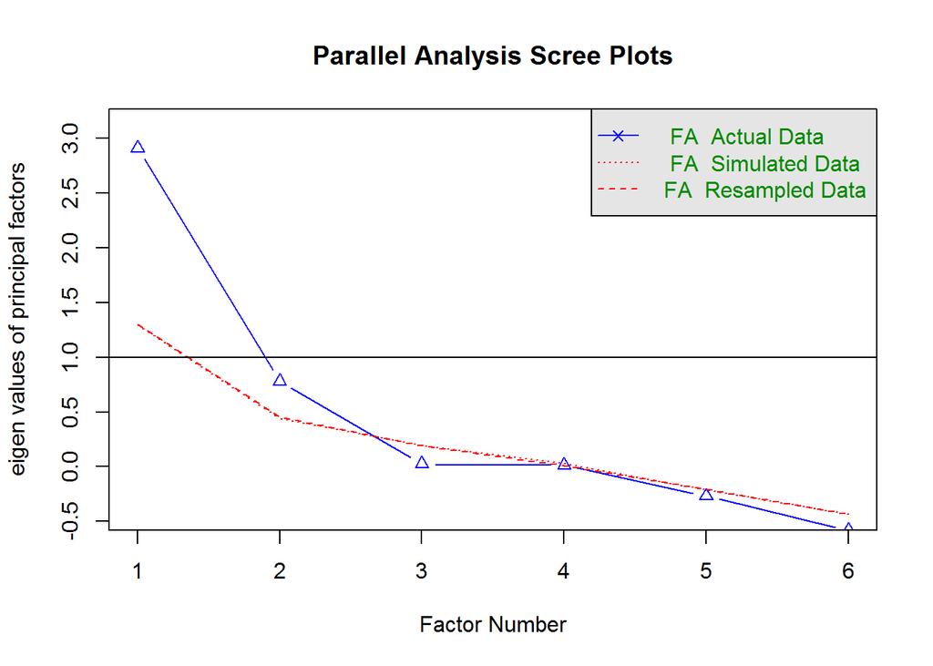

```
## Parallel analysis suggests that the number of factors =  2  and the number of components =  NA
```

```r
#insumo basico para hacer el analisis factorial (DIARGRAMA DE SEDIMENTACION nos dice cuantos factores deberiamos calcular)
fa.parallel(subdata, fm = 'ML', fa = 'fa')
```

Solicitamos el número de factores. Considerar si se presentan mensajes de alerta.

```r
library(GPArotation)
factorial <- fa(subdata,nfactors = 2, cor = 'mixed', rotate = "varimax",fm="minres")
#correlacion mixta, rotacion
```

## Paso 4: Visualizamos el EFA solicitado

Vemos el resultado inicial: - mayor sea el numero mas aporta al factor. uando una vairbale tiene loadings en dos factores quiere decir que aporta a los dos factores

```r
print(factorial$loadings)
```

```
##
## Loadings:
##                              MR1    MR2
## vias_pavimentadas                    0.424
## agua                          0.934
## desague                       0.916  0.149
## electrificacion               0.964
## PBI_percapita                 0.468  0.888
## presupuestopublico_percapita         0.605
##
##                  MR1   MR2
## SS loadings    2.869 1.369
## Proportion Var 0.478 0.228
## Cumulative Var 0.478 0.706
```

Vemos el resultado mejorado: Cuando logramos que cada variable se vaya a un factor, tenemos una estructura simple.

```r
print(factorial$loadings, cutoff = 0.5)
```

```
##
## Loadings:
##                              MR1    MR2
## vias_pavimentadas
## agua                          0.934
## desague                       0.916
## electrificacion               0.964
## PBI_percapita                        0.888
## presupuestopublico_percapita         0.605
##
##                  MR1   MR2
## SS loadings    2.869 1.369
## Proportion Var 0.478 0.228
## Cumulative Var 0.478 0.706
```

- al ver que vias no aporta, SERIA MEJOR HACER DE NUEVO EL ANALISIS FACTORIAL SIN VIAS, o decides quedarte. Depende del diseño del trabajo
- VAR. ACUMUAD:porcentaje de virbilidad, el factor uno 47%, el factro 2 es 70%

Podemos visualizar los variables y su relación con las latentes creadas:

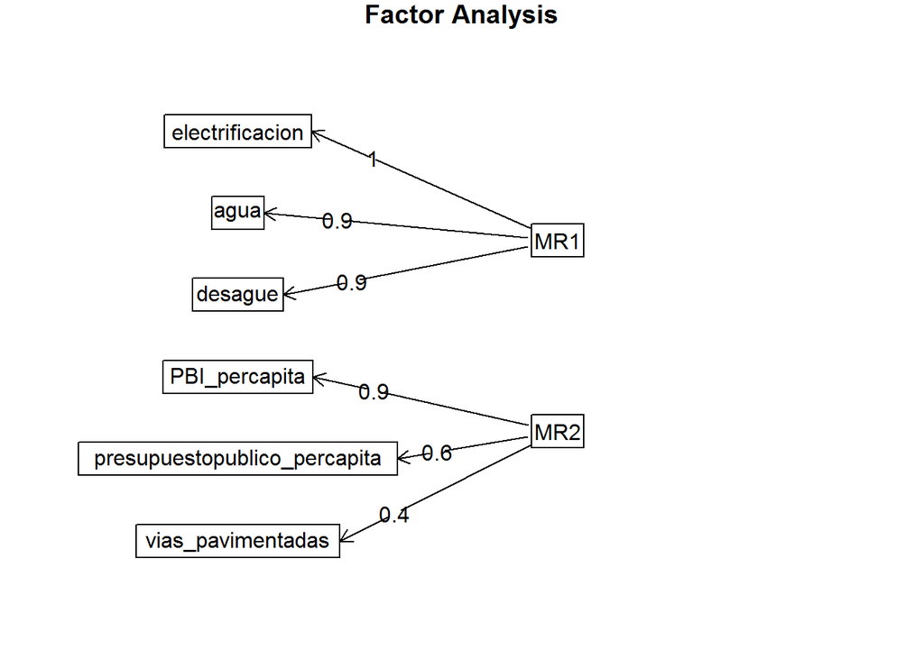

```r
fa.diagram(factorial)
```

## Paso 5: Evaluamos el Análisis Factorial Exploratorio solicitado (comprobamos validez AF)

- ¿La Raíz del error cuadrático medio corregida está cerca a cero? - Valores cercano a 0 indica un buen ajuste. Si no sale cerca al 0 eso significa que el análisis extraído no es suficientemente válido. En ese caso se REPORTA.

```r
factorial$crms
```

```
## [1] 0.08261519
```

```r
factorial$RMSEA
```

```
##      RMSEA      lower      upper confidence
##  0.3233485  0.1527133  0.5340611  0.9000000
```

- ¿El índice de Tucker-Lewis es mayor a 0.9? Este índice tiende a 1 para modelos con muy buen ajuste, considerándose aceptables valores superiores a 0.90, aunque lo ideal sería valores mayores a 0.95.Si sale menor a 0.9 indica insuficiencia de validez. En ese caso se reporta.

```r
factorial$TLI
```

```
## [1] 0.5212291
```

- ¿Qué variables aportaron mas a los factores?
  - aprota mas PBI y menos vias

```r
#sort es una funcion para ordenar de menor a mayor
sort(factorial$communality)
```

```
##            vias_pavimentadas presupuestopublico_percapita
##                    0.1888712                    0.3676602
##                      desague                         agua
##                    0.8605013                    0.8758996
##              electrificacion                PBI_percapita
##                    0.9367019                    1.0082507
```

- ¿Qué variables contribuyen a mas de un factor?

```r
sort(factorial$complexity)
```

```
## presupuestopublico_percapita                         agua
##                     1.006075                     1.007816
##              electrificacion                      desague
##                     1.017507                     1.053256
##            vias_pavimentadas                PBI_percapita
##                     1.098506                     1.516497
```

```r
#cada una de las variables, caada variable aporta a un factor.Pero tiene decimales, es deicr, aporta a 1.51 factores
#que variable aporta a mas de un factor: PBI
#que vairable aporta a menos de un factor: Presupuesto Publico
```

## Paso 6: Posibles valores proyectados

¿Qué nombres les darías?

Podemos crear un data set con sólo los factores creados

```r
factorial_casos<-as.data.frame(factorial$scores)
head(factorial_casos)
```

|  | MR1 | MR2 |
| --- | --- | --- |
| 1 | -1.2123710 | -0.1879479 |
| 2 | 0.5244837 | 0.4357522 |
| 3 | -0.5214367 | 0.7148069 |
| 4 | 1.2143593 | 0.7401245 |
| 5 | -0.1678911 | -0.2219972 |
| 6 | -0.5750133 | -0.2651315 |

```r
summary(factorial_casos)
```

```
##       MR1                MR2
##  Min.   :-1.48355   Min.   :-1.6099
##  1st Qu.:-0.98449   1st Qu.:-0.4329
##  Median :-0.04854   Median :-0.1260
##  Mean   : 0.00000   Mean   : 0.0000
##  3rd Qu.: 0.97628   3rd Qu.: 0.3127
##  Max.   : 1.45470   Max.   : 4.0370
```

o incluirlos en nuestro subset original

```r
subdata$factor1<- factorial_casos$MR1
subdata$factor2<- factorial_casos$MR2
```

# Ejercicio 2: Realice un análisis factorial con todos los pasos indicados de la base de distritos y variables del sistema político electoral

Abrimos la base de datos

```r
library(rio)
electoral<- import("https://github.com/DataPolitica/salidas/raw/master/Data/ERM2010_Distrital.xlsx")
head(electoral)
```

|  | UBIGEO | REGION | PROVINCIA | DISTRITO | NEP 2010 | NP 2010 | HIPERFRACCIONAMIENTO 2010 | VOLATILIDAD TOTAL 2010 | CONCENTRACION 2010 | HERFINDHAL HIRSCHMAN 2010 | COMPETITIVIDAD 2010 |
| --- | --- | --- | --- | --- | --- | --- | --- | --- | --- | --- | --- |
| 1 | 010102 | AMAZONAS | CHACHAPOYAS | ASUNCION | 2.292 | 1.465 | 2.588 | 0.002 | 0.841 | 0.436 | 0.338 |
| 2 | 010103 | AMAZONAS | CHACHAPOYAS | BALSAS | 2.457 | 1.743 | 2.676 | 1.000 | 0.850 | 0.407 | 0.216 |
| 3 | 010104 | AMAZONAS | CHACHAPOYAS | CHETO | 3.432 | 3.142 | 3.615 | 1.000 | 0.659 | 0.291 | 0.002 |
| 4 | 010105 | AMAZONAS | CHACHAPOYAS | CHILIQUIN | 3.409 | 1.983 | 4.054 | 0.033 | 0.649 | 0.293 | 0.265 |
| 5 | 010106 | AMAZONAS | CHACHAPOYAS | CHUQUIBAMBA | 4.575 | 3.871 | 5.215 | 0.071 | 0.566 | 0.219 | 0.005 |
| 6 | 010107 | AMAZONAS | CHACHAPOYAS | GRANADA | 2.942 | 2.147 | 3.326 | 0.027 | 0.787 | 0.340 | 0.124 |

Realizamos un subset y nos quedamos con las variables que utilizaremos. Lo llamaremos **subdata**:

```r
subdata<- electoral[,c(5:11)]
```

# Ejercicio 3: IDE

Abrimos la base de datos

```r
ide<- import("https://github.com/DataPolitica/salidas/raw/master/Data/IDE.sav")
```

Realizamos un subset y nos quedamos con las variables que utilizaremos. Lo llamaremos **subdata**:

```r
subdata<- ide[,c(6:10)]
```

# Ejercicio 4: DEMOCRACY INDEX

Abrimos la base de datos

```r
demo<- import("https://github.com/DataPolitica/salidas/raw/master/Data/demo.xlsx")
```

Realizamos un subset y nos quedamos con las variables que utilizaremos. Lo llamaremos **subdata**:

```r
str(demo)
```

```
## 'data.frame':    167 obs. of  8 variables:
##  $ Pais                   : chr  "Noruega" "Islandia" "Suecia" "Nueva Zelanda" ...
##  $ PUNT                   : chr  "9.87" "9.58" "9.39" "9.27" ...
##  $ Pluralismo             : chr  "10.00" "10.00" "9.58" "10.00" ...
##  $ Funcionamiento_gobierno: chr  "9.64" "9.29" "9.64" "9.29" ...
##  $ Participacion_politica : chr  "10.00" "8.89" "8.33" "8.89" ...
##  $ Cultura_policita       : chr  "10.00" "10.00" "10.00" "8.13" ...
##  $ Derechos_civiles       : chr  "9.71" "9.71" "9.41" "10.00" ...
##  $ Cate                   : chr  "Democracia plena" "Democracia plena" "Democracia plena" "Democracia plena" ...
```

```r
demo[,-c(1,2,8)]=lapply(demo[,-c(1,2,8)], as.numeric)
subdata<- demo[,c(3:7)]
subdata<-na.omit(subdata)
str(subdata)
```

```
## 'data.frame':    167 obs. of  5 variables:
##  $ Pluralismo             : num  10 10 9.58 10 10 9.58 10 9.58 10 9.58 ...
##  $ Funcionamiento_gobierno: num  9.64 9.29 9.64 9.29 8.93 7.86 9.29 9.64 8.93 9.29 ...
##  $ Participacion_politica : num  10 8.89 8.33 8.89 8.33 8.33 8.33 7.78 7.78 7.78 ...
##  $ Cultura_policita       : num  10 10 10 8.13 8.75 10 9.38 8.75 8.75 9.38 ...
##  $ Derechos_civiles       : num  9.71 9.71 9.41 10 9.71 10 9.12 10 10 9.12 ...
```